# ExtraaLearn Project

#### **RBF Kernel**

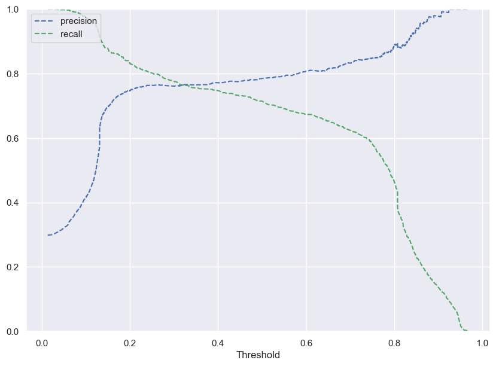

```python
# Predict on train data
svm_rbf=SVC(kernel='rbf',probability=True)
# Fit the model
svm_rbf.fit(X_train_scaled,y_train)
# Predict on train data
y_scores_svm=svm_rbf.predict_proba(X_train_scaled)

precisions_svm, recalls_svm, thresholds_svm = precision_recall_curve(y_train, y_scores_svm[:,1])

# Plot values of precisions, recalls, and thresholds
plt.figure(figsize=(10,7))
plt.plot(thresholds_svm, precisions_svm[:-1], 'b--', label='precision')
plt.plot(thresholds_svm, recalls_svm[:-1], 'g--', label = 'recall')
plt.xlabel('Threshold')
plt.legend(loc='upper left')
plt.ylim([0,1])
plt.show()
```

```
              precision    recall  f1-score   support

           0       0.90      0.90      0.90      2264
           1       0.76      0.76      0.76       964

    accuracy                           0.86      3228
   macro avg       0.83      0.83      0.83      3228
weighted avg       0.86      0.86      0.86      3228
```

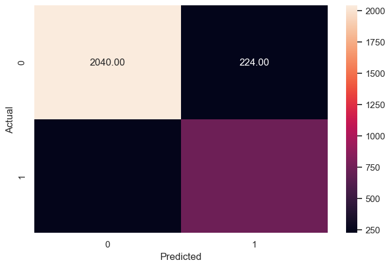

```python
# Fitting SVM with optimum threshold
optimal_threshold_svm=.35
y_pred_train = svm_rbf.predict_proba(X_train_scaled)

metrics_score(y_train, y_pred_train[:,1]>optimal_threshold_svm)
```

##### Checking the performance of the model on train and test data using the optimal threshold.

```
              precision    recall  f1-score   support

           0       0.88      0.89      0.88       971
           1       0.73      0.71      0.72       413

    accuracy                           0.83      1384
   macro avg       0.80      0.80      0.80      1384
weighted avg       0.83      0.83      0.83      1384
```

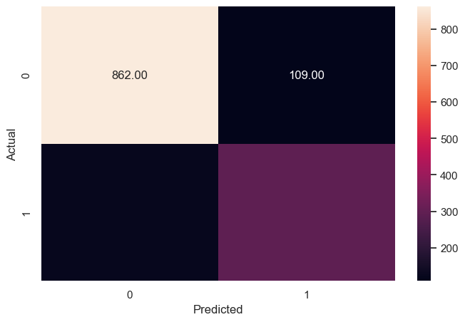

```python
optimal_threshold_svm=.35
y_pred_test = svm_rbf.predict_proba(X_test_scaled)
metrics_score(y_test, y_pred_test[:,1]>optimal_threshold_svm)
```

```python
# Creating objects out of the results to allow for summarisation
SVM_train_accuracy_ot = 0.86
SVM_train_precision_01_ot = 0.76
SVM_train_recall_01_ot = 0.76
SVM_train_f1_01_ot = 0.76
SVM_train_support_01_ot = 964

SVM_test_accuracy_ot =  0.83
SVM_test_precision_01_ot = 0.73
SVM_test_recall_01_ot = 0.71
SVM_test_f1_01_ot = 0.72
SVM_test_support_01_ot = 413
```

```python
# Creating a summary table of the performance on test for status = 1
summary_SVM = pd.DataFrame({
    'Metric ': ['Accuracy', 'Precision', 'Recall', 'F1-score', 'Support'],
    'Train': [SVM_train_accuracy, SVM_train_precision_01, SVM_train_recall_01, SVM_train_f1_01, SVM_train_support_01],
    'Test': [SVM_test_accuracy, SVM_test_precision_01, SVM_test_recall_01, SVM_test_f1_01, SVM_test_support_01]
})

summary_SVM_ot = pd.DataFrame({
    'OT Metric': ['Accuracy', 'Precision', 'Recall', 'F1-score', 'Support'],
    'Train': [SVM_train_accuracy_ot, SVM_train_precision_01_ot, SVM_train_recall_01_ot, SVM_train_f1_01_ot, SVM_train_support_01_ot],
    'Test': [SVM_test_accuracy_ot, SVM_test_precision_01_ot, SVM_test_recall_01_ot, SVM_test_f1_01_ot, SVM_test_support_01_ot]
})
```

```python
# Viewing the summary tables side-by-side using pd.concatenate() function
SVM_result = pd.concat([summary_SVM, summary_SVM_ot], axis=1)
SVM_result.drop(index=4, inplace=True)
SVM_result
```

|  | Metric | Train | Test | OT Metric | Train | Test |
| --- | --- | --- | --- | --- | --- | --- |
| 0 | Accuracy | 0.82 | 0.83 | Accuracy | 0.86 | 0.83 |
| 1 | Precision | 0.72 | 0.73 | Precision | 0.76 | 0.73 |
| 2 | Recall | 0.68 | 0.68 | Recall | 0.76 | 0.71 |
| 3 | F1-score | 0.70 | 0.70 | F1-score | 0.76 | 0.72 |

#### Observations:

- At the optimal threshold of .35, the model performance has improved slightly. The recall has improved from 0.68 to 0.71 which is a ~3% increase.
- Since we used used the rbf kernel, it indicates that the model performs better with a non-linear kernel.
- The higher recall suggests that **this model should perform relatively well** in predicting the probability of leads converting into paying customers.

### Decision Tree model

```python
# Building the decision tree model
dt = DecisionTreeClassifier(class_weight = 'balanced', random_state = 1)
```

```python
# Fitting decision tree model
dt.fit(X_train, y_train)
```

```
DecisionTreeClassifier(class_weight='balanced', random_state=1)
```

```python
### Checking the performance of the model on train and test data
```

#### Checking performance on the training data set

```
              precision    recall  f1-score   support

           0       1.00      1.00      1.00      2264
           1       1.00      1.00      1.00       964

    accuracy                           1.00      3228
   macro avg       1.00      1.00      1.00      3228
weighted avg       1.00      1.00      1.00      3228
```

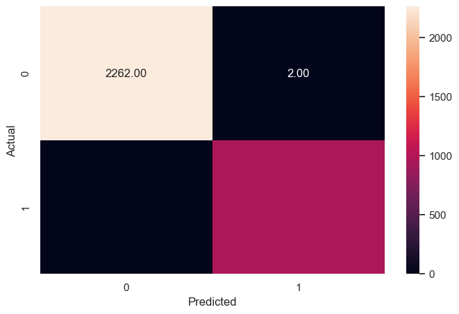

```python
# Checking performance on the training dataset
y_train_pred_dt = dt.predict(X_train)

metrics_score(y_train, y_train_pred_dt)
```

#### Observations:

- The Decision tree is giving a 100% score for all metrics on the training dataset.

#### Checking performance on the test data set

```
              precision    recall  f1-score   support

           0       0.85      0.85      0.85       971
           1       0.65      0.64      0.64       413

    accuracy                           0.79      1384
   macro avg       0.75      0.75      0.75      1384
weighted avg       0.79      0.79      0.79      1384
```

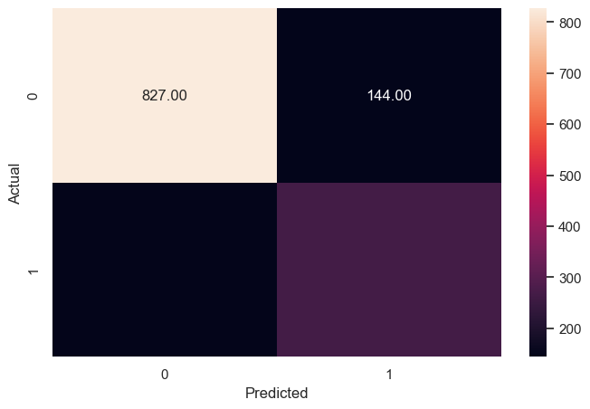

```python
# Checking performance on the test dataset
y_test_pred_dt = dt.predict(X_test)

metrics_score(y_test, y_test_pred_dt)
```

#### Observations:

- The Decision tree is giving a 100% score for all metrics on the training dataset but **not so well on the test data** as the recall is 0.64 in comparison to 1 for the training dataset, i.e., the Decision Tree is overfitting the training data.
- The precision on the test data suggests that there's a 35% (1 - 0.65) chance that the model will predict that a lead will convert although he/she would not which is not a very good margin.

**Plotting the feature importances and checking the most important features.**

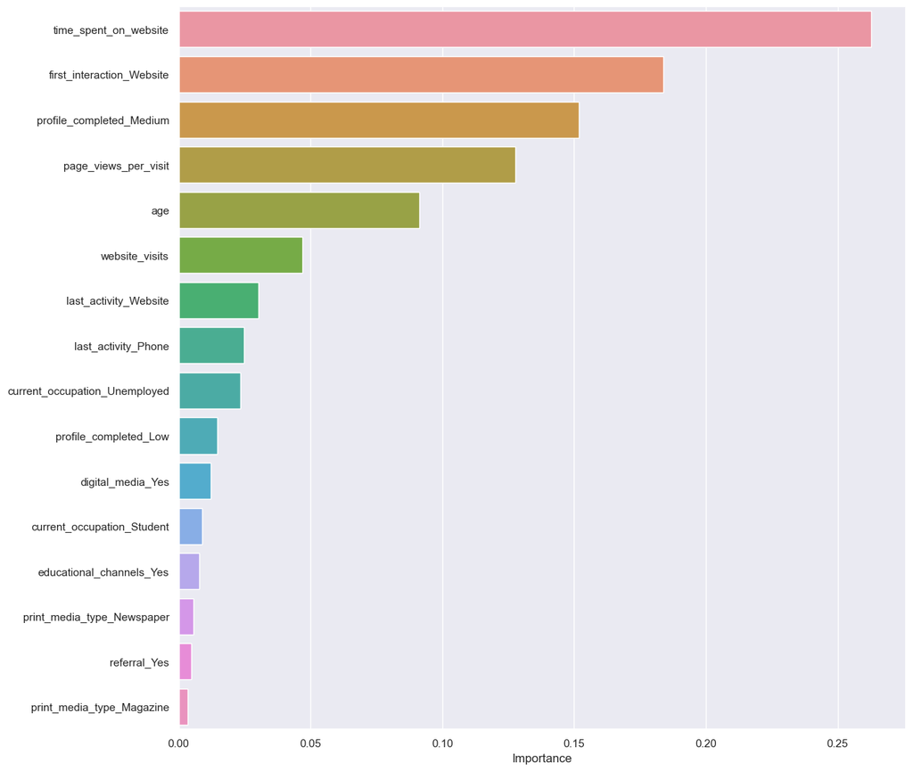

```python
# Plot the feature importance

importances = dt.feature_importances_
columns = X.columns
importance_df = pd.DataFrame(importances, index = columns, columns = ['Importance']).sort_values(by = 'Importance', ascending = False)
plt.figure(figsize = (13, 13))
sns.barplot(data = importance_df, x = importance_df.Importance, y = importance_df.index)
```

#### Observations:

The **most important feature** according to the Decision Tree is **time spent on website**, followed by **first interaction on website**, **profile completed medium**, **page views per visit** and **age**. This suggests thatyhpotential paying customers spend a certain amount of time on the website, had their first interaction with the company on the website, have completed their profiles at least to a medium level, have viewed a certain number of pages per website visit and are of a certain age category.

Features with less importance but worth being concerned about include **website visits**, **last activity being on the website**, **last activity phone** and **current_occupation unemployed**.

#### **Visualizing the Decision Tree**

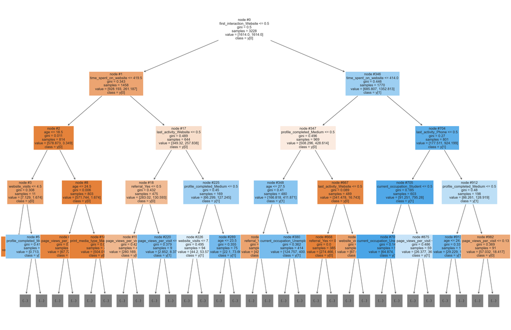

```python
# Visualising the model with max_depth = 4
features = list(X.columns)

plt.figure(figsize = (30, 20))

tree.plot_tree(dt, max_depth = 4, feature_names = features, filled = True, fontsize = 12, node_ids = True, class_names = True)

plt.show()
```

** Notes about the Decision Tree:**

- The blue leaves represent conversions i.e., **[y1]**
- The orange leaves represnt non-conversions i.e., **[y0]**
- The increase in colour instensity indicates higher number of observations in a leaf

#### Observations:

**Interpretation and Conclusions:**

#### Do we need to prune the tree?

- Since the Decision Tree is overfitting on the training dataset, we would want to reduce this to minimise misclassification.
- Although pruning the Decision Tree could possibly help with reducing overfitting, it requires more computation to arrive at the rate of error in misclassification and entropy i.e., information loss and is thus costly.
- Furthermore, another important consideration apart from overfitting, is the quality of the classifier. The performance of the Decision Tree on the test set reveals that using all the features, the classifier will be 65% correct in predicting that a lead will be converted. The recall score indicates 64% of the conversions were predicted correctly. Considering the f1-score which is defined as the **Harmonic Mean of the Precision and Recall**, we can conclude that the Decision tree classifier has a 64% chance of being correct and not miss any correct predictions.
- Therefore instead of pruning, alternatives to pruning in order to improve the model performance and tackle overfitting include tuning the Decision Tree's hyperpameters or employing ensemble methods which are trained on different subsets of the dataset.

#### Motivation for tuning the hyperparemeters using GridSearch CV:

- The reason behind tuning is to see if the model performance will be improved by adjusting hyperparameters
- The algorithm finds the optimal values for the hyperparameters (e.g., tree depth, minimum samples) increasing the generalization and preventing overfitting.

#### Checking the performance of the model on the train and test data using the tuned model

```python
# Choosing the type of classifier
dtree_estimator = DecisionTreeClassifier(class_weight='balanced', random_state=1)

# Grid of parameters to choose from
parameters = {'max_depth': np.arange(2, 7),
              'criterion': ['gini', 'entropy'],
              'min_samples_leaf': [5, 10, 20, 25]
             }

# Type of scoring used to compare parameter combinations
import sklearn.metrics as metrics
scorer = metrics.make_scorer(recall_score, pos_label = 1)

# Run the grid search
gridCV = GridSearchCV(dtree_estimator, parameters, scoring = scorer, cv = 10)

# Fitting the grid search on the train data
gridCV = gridCV.fit(X_train, y_train)

# Set the classifier to the best combination of parameters
dtree_estimator = gridCV.best_estimator_

# Fit the best estimator to the data
dtree_estimator.fit(X_train, y_train)
```

```
DecisionTreeClassifier(class_weight='balanced', max_depth=3, min_samples_leaf=5,
                       random_state=1)
```

```
              precision    recall  f1-score   support

           0       0.95      0.75      0.84      2264
           1       0.60      0.91      0.72       964

    accuracy                           0.79      3228
   macro avg       0.78      0.83      0.78      3228
weighted avg       0.85      0.79      0.80      3228
```

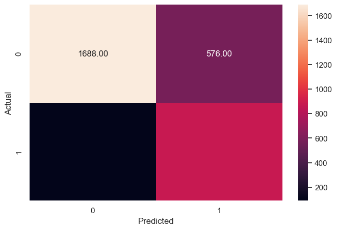

```python
# Checking performance on the training dataset
y_train_pred_dt = dtree_estimator.predict(X_train)

metrics_score(y_train, y_train_pred_dt)
```

```
              precision    recall  f1-score   support

           0       0.94      0.73      0.82       971
           1       0.58      0.89      0.70       413

    accuracy                           0.78      1384
   macro avg       0.76      0.81      0.76      1384
weighted avg       0.83      0.78      0.79      1384
```

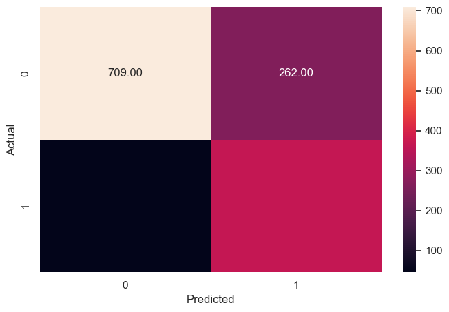

```python
# Checking performance on the test dataset
y_test_pred_dt = dtree_estimator.predict(X_test)

metrics_score(y_test, y_test_pred_dt)
```

```python
# Creating objects out of the results from the initial Decision Tree regressor to allow for summarisation
DT_train_accuracy = 1.00
DT_train_precision_01 = 1.00
DT_train_recall_01 = 1.00
DT_train_f1_01 = 1.00
DT_train_support_01 = 964

DT_test_accuracy =  0.79
DT_test_precision_01 = 0.65
DT_test_recall_01 = 0.64
DT_test_f1_01 = 0.64
DT_test_support_01 = 413
```

```python
# Creating objects out of the results of the tuned model to allow for summarisation
DT_train_accuracy_tuned = 0.79
DT_train_precision_01_tuned = 0.60
DT_train_recall_01_tuned = 0.91
DT_train_f1_01_tuned = 0.72
DT_train_support_01_tuned = 964

DT_test_accuracy_tuned =  0.78
DT_test_precision_01_tuned = 0.58
DT_test_recall_01_tuned = 0.89
DT_test_f1_01_tuned = 0.70
DT_test_support_01_tuned = 413
```

```python
# Creating a summary table of the performance on test for status = 1
summary_DT = pd.DataFrame({
    'Metric ': ['Accuracy', 'Precision', 'Recall', 'F1-score', 'Support'],
    'Train': [DT_train_accuracy, DT_train_precision_01, DT_train_recall_01, DT_train_f1_01, DT_train_support_01],
    'Test': [DT_test_accuracy, DT_test_precision_01, DT_test_recall_01, DT_test_f1_01, DT_test_support_01]
})

summary_DT_tuned = pd.DataFrame({
    'Tuned Metric ': ['Accuracy', 'Precision', 'Recall', 'F1-score', 'Support'],
    'Train': [DT_train_accuracy_tuned, DT_train_precision_01_tuned, DT_train_recall_01_tuned, DT_train_f1_01_tuned, DT_train_support_01_tuned],
    'Test': [DT_test_accuracy_tuned, DT_test_precision_01_tuned, DT_test_recall_01_tuned, DT_test_f1_01_tuned, DT_test_support_01_tuned]
})
```

```python
# Viewing the summary tables side-by-side using pd.concatenate() function
DT_result = pd.concat([summary_DT, summary_DT_tuned], axis=1)
DT_result.drop(index=4, inplace=True)
DT_result
```

|  | Metric | Train | Test | Tuned Metric | Train | Test |
| --- | --- | --- | --- | --- | --- | --- |
| 0 | Accuracy | 1.00 | 0.79 | Accuracy | 0.79 | 0.78 |
| 1 | Precision | 1.00 | 0.65 | Precision | 0.60 | 0.58 |
| 2 | Recall | 1.00 | 0.64 | Recall | 0.91 | 0.89 |
| 3 | F1-score | 1.00 | 0.64 | F1-score | 0.72 | 0.70 |

### **Random Forest**

The last model we will consider in search of the best model for the problem of predicting the type of leads which will convert is the Random Forest regressor.

#### Building the Random Forest model

```python
# Fitting the Random Forest classifier on the training data
rf_estimator = RandomForestClassifier(class_weight = 'balanced', random_state = 1)

rf_estimator.fit(X_train, y_train)
```

```
RandomForestClassifier(class_weight='balanced', random_state=1)
```

#### Checking the performance of the model on train and test data.

```
              precision    recall  f1-score   support

           0       1.00      1.00      1.00      2264
           1       1.00      1.00      1.00       964

    accuracy                           1.00      3228
   macro avg       1.00      1.00      1.00      3228
weighted avg       1.00      1.00      1.00      3228
```

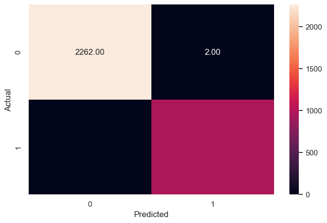

```python
# Checking performance on the training data
y_pred_train_rf = rf_estimator.predict(X_train)

metrics_score(y_train, y_pred_train_rf)
```

#### Observations:

- For all the metrics in the training dataset, the Random Forest gives a 100% score.

```
              precision    recall  f1-score   support

           0       0.89      0.92      0.91       971
           1       0.80      0.72      0.76       413

    accuracy                           0.86      1384
   macro avg       0.84      0.82      0.83      1384
weighted avg       0.86      0.86      0.86      1384
```

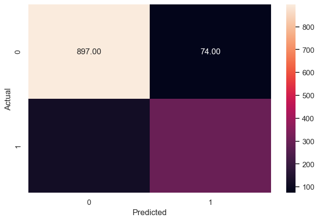

```python
# Checking performance on the testing data
y_pred_test_rf = rf_estimator.predict(X_test)

metrics_score(y_test, y_pred_test_rf)
```

#### Checking the feature importance of the Random Forest

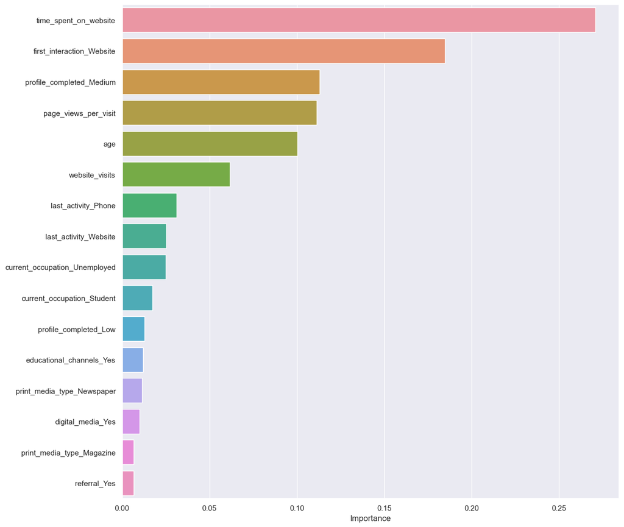

```python
importances = rf_estimator.feature_importances_
columns = X.columns
importance_df = pd.DataFrame(importances, index = columns, columns = ['Importance']).sort_values(by = 'Importance', ascending = False)
plt.figure(figsize = (13, 13))
sns.barplot(data = importance_df, x = importance_df.Importance, y = importance_df.index)
```

#### Observations:

- According to the Random Forest, the important features are **time spent on website**, **first interaction on website**, **profile completed medium**, **page views per visit**, **age** and **website visits**. The result is somewhat similar to the that of the Decision Tree.
- The interpretation is that leads who convert to paying customers spend a certain amount of time on the website, had their first interaction with the company on the website, have completed their profiles at least to a medium level, have viewed a certain number of pages per website visit, are of a certain age category and have visited the website a certain number of times.
- Features with less importance but informing the likelihood to convert include **last activity phone** and **last activity website** which indicates the level of interaction with the company by leads is a meaningful indicator of the chances of becoming a paying customer.
- **Current occupation unemployed** and **current occupation student** are also features that influence conversion. This is intuitive as such leads are most likely motivated to increase their skills set to be improve their career prospects.

#### Checking the performance of the tuned Random Forest model on the train and test data

```python
# Choose the type of classifier
rf_estimator_tuned = RandomForestClassifier(class_weight = 'balanced', random_state = 1)

# Grid of parameters to choose from
params_rf = {
        "n_estimators": [100, 250, 500],
        "min_samples_leaf": np.arange(1, 4, 1),
        "max_features": [0.7, 0.9, 'auto'],
}


# Type of scoring used to compare parameter combinations - recall score for class 1
scorer = metrics.make_scorer(recall_score, pos_label = 1)

# Run the grid search
grid_obj = GridSearchCV(rf_estimator_tuned, params_rf, scoring = scorer, cv = 5)

grid_obj = grid_obj.fit(X_train, y_train)

# Set the classifier to the best combination of parameters
rf_estimator_tuned = grid_obj.best_estimator_
```

```python
# Fitting the tuned model
rf_estimator_tuned.fit(X_train, y_train)
```

```
RandomForestClassifier(class_weight='balanced', max_features='auto',
                       min_samples_leaf=3, n_estimators=500, random_state=1)
```

```
              precision    recall  f1-score   support

           0       0.97      0.93      0.95      2264
           1       0.85      0.94      0.89       964

    accuracy                           0.93      3228
   macro avg       0.91      0.93      0.92      3228
weighted avg       0.93      0.93      0.93      3228
```

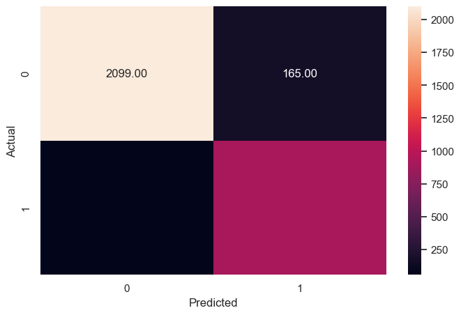

```python
# Checking performance on the training data
y_pred_train_rf_tuned = rf_estimator_tuned.predict(X_train)

metrics_score(y_train, y_pred_train_rf_tuned)
```

```
              precision    recall  f1-score   support

           0       0.90      0.88      0.89       971
           1       0.74      0.78      0.76       413

    accuracy                           0.85      1384
   macro avg       0.82      0.83      0.83      1384
weighted avg       0.85      0.85      0.85      1384
```

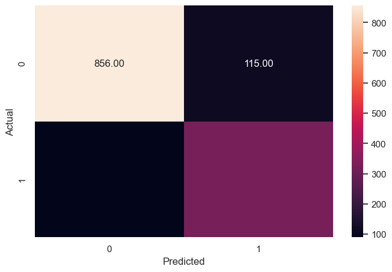

```python
# Checking performance on the test data
y_pred_test_rf_tuned = rf_estimator_tuned.predict(X_test)

metrics_score(y_test, y_pred_test_rf_tuned)
```

```python
# Creating objects out of the results from the initial Random Forest regressor to allow for summarisation
RF_train_accuracy = 1.00
RF_train_precision_01 = 1.00
RF_train_recall_01 = 1.00
RF_train_f1_01 = 1.00
RF_train_support_01 = 964

RF_test_accuracy =  0.86
RF_test_precision_01 = 0.80
RF_test_recall_01 = 0.72
RF_test_f1_01 = 0.76
RF_test_support_01 = 413
```

```python
# Creating objects out of the results of the tuned model to allow for summarisation
RF_train_accuracy_tuned = 0.93
RF_train_precision_01_tuned = 0.85
RF_train_recall_01_tuned = 0.94
RF_train_f1_01_tuned = 0.89
RF_train_support_01_tuned = 964

RF_test_accuracy_tuned =  0.85
RF_test_precision_01_tuned = 0.74
RF_test_recall_01_tuned = 0.78
RF_test_f1_01_tuned = 0.76
RF_test_support_01_tuned = 413
```

```python
# Creating a summary table of the performance on test for status = 1
summary_RF = pd.DataFrame({
    'Metric ': ['Accuracy', 'Precision', 'Recall', 'F1-score', 'Support'],
    'Train': [RF_train_accuracy, RF_train_precision_01, RF_train_recall_01, RF_train_f1_01, RF_train_support_01],
    'Test': [RF_test_accuracy, RF_test_precision_01, RF_test_recall_01, RF_test_f1_01, RF_test_support_01]
})

summary_RF_tuned = pd.DataFrame({
    'Tuned Metric ': ['Accuracy', 'Precision', 'Recall', 'F1-score', 'Support'],
    'Train': [RF_train_accuracy_tuned, RF_train_precision_01_tuned, RF_train_recall_01_tuned, RF_train_f1_01_tuned, RF_train_support_01_tuned],
    'Test': [RF_test_accuracy_tuned, RF_test_precision_01_tuned, RF_test_recall_01_tuned, RF_test_f1_01_tuned, RF_test_support_01_tuned]
})
```

```python
# Viewing the summary tables side-by-side using pd.concatenate() function
RF_result = pd.concat([summary_RF, summary_RF_tuned], axis=1)
RF_result.drop(index=4, inplace=True)
RF_result
```

|  | Metric | Train | Test | Tuned Metric | Train | Test |
| --- | --- | --- | --- | --- | --- | --- |
| 0 | Accuracy | 1.00 | 0.86 | Accuracy | 0.93 | 0.85 |
| 1 | Precision | 1.00 | 0.80 | Precision | 0.85 | 0.74 |
| 2 | Recall | 1.00 | 0.72 | Recall | 0.94 | 0.78 |
| 3 | F1-score | 1.00 | 0.76 | F1-score | 0.89 | 0.76 |

#### Observations:

- The tuned model shows some signs of overfitting the training dataset given some of the very high metrics. However, it shows a good performance on the test data.
- The recall for class 1 has improved slightly **~0.06** with a small decrease in precision **~0.06**.

## Conclusion:

```python
# Creating a summary table of the results of the models to compare their performance
Model_comparison = pd.concat([lr_result, SVM_result, DT_result, RF_result], axis=1)
Model_comparison.drop(index =[1,2], inplace=True)
Model_comparison
```

|  | Metric | Train | Test | OT Metric | Train | Test | Metric | Train | Test | OT Metric | ... | Test | Tuned Metric | Train | Test | Metric | Train | Test | Tuned Metric | Train | Test |
| --- | --- | --- | --- | --- | --- | --- | --- | --- | --- | --- | --- | --- | --- | --- | --- | --- | --- | --- | --- | --- | --- |
| 0 | Accuracy | 0.82 | 0.83 | Accuracy | 0.82 | 0.83 | Accuracy | 0.82 | 0.83 | Accuracy | ... | 0.79 | Accuracy | 0.79 | 0.78 | Accuracy | 1.00 | 0.86 | Accuracy | 0.93 | 0.85 |
| 3 | F1-score | 0.68 | 0.69 | F1-score | 0.70 | 0.70 | F1-score | 0.70 | 0.70 | F1-score | ... | 0.64 | F1-score | 0.72 | 0.70 | F1-score | 1.00 | 0.76 | F1-score | 0.89 | 0.76 |

2 rows × 24 columns

### Actionable Insights and Recommendations

- In this anaysis, we were able to identify the key factors that are associated with leads eventually converting to paying customers of Extraalearn.
- Our final model based on the Random Forest regressor showed that the important features which influence conversion are mainly the level of interaction the leads have with the company, particularly on the website.
- Therefore the company's digital marketing efforts must focus on:
  - making an **impactful first impression** on leads when they visit the website for the first time
  - publishing **website content that is engaging and relevant**
  - ensuring a friendly user-experience
  - adding consenting leads to periodic newsletters that have a link to the website
  - paying attention to leads with **medium complete profiles** by for instance notifying them that their profiles are incomplete as a prompt to logon to the website and finish the process

Such initiaves would help increase the rate of **website visits**, **page views per visit** and make **time spent on website** by leads worthwhile in their information-gathering and decision-making processes.

- We observed that **age** is also an important determining factor in conversion. With the average lead being 46 years of age, the company's market segmentation strategy would need to be reviewed to check if it aligns with this insight. Employing methods such as clustering would further assist with understanding the age demographic of leads and drivers of conversion.
- The company must allocate resources for personal interaction or **one-to-one communication** with leads given the importance of the **last activity phone** feature.
- Lastly, the needs of leads who are unemployed or students must be considered and accomodated in order to increase their probability to convert. *E.g.,* offering more personal support such as guidance prior to registration and financial assistance.